# Letting the Slope Depend on the Group

Lesson 32 — Multiple Regression with Interaction Terms

Lt Col Cho

## Where we left off

- **Is one shared slope an adequate description of all three species?**

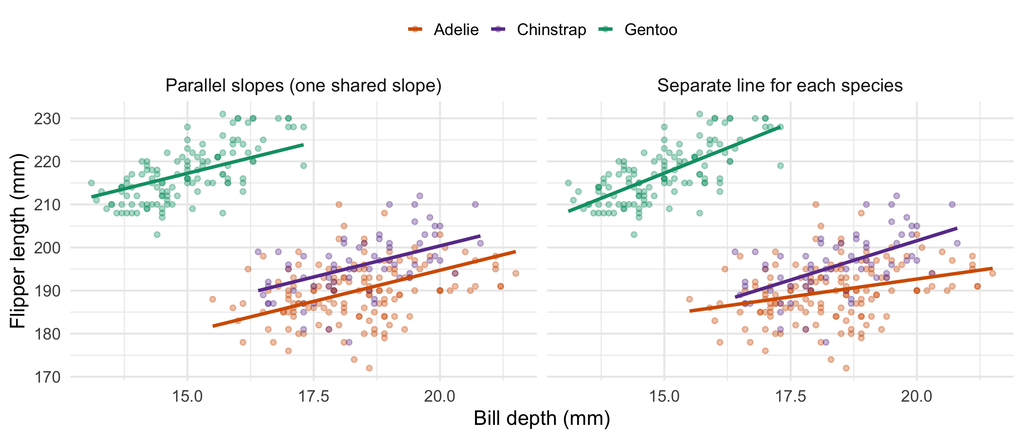

| Slope on `bill_depth_mm` | Adelie | Chinstrap | Gentoo |
| --- | --- | --- | --- |
| Parallel slopes model | 2.89 | 2.89 | 2.89 |
| Separate least squares line | 1.65 | 3.64 | 4.67 |

Slopes are in mm of flipper length per mm of bill depth.

## The interaction model

**① Model specification**

$$\begin{aligned}
\text{flipper} = \beta_0 &+ \beta_1 \times \text{bill depth} \\
&+ \beta_2 \times \text{speciesChinstrap} + \beta_3 \times \text{speciesGentoo} \\
&+ \beta_{12} \times \text{bill depth} \times \text{speciesChinstrap} + \beta_{13} \times \text{bill depth} \times \text{speciesGentoo} + \varepsilon
\end{aligned}$$

**② Fit the model:** `*` between two predictors includes both predictors **and** their interaction.

```r
interaction_mod <- lm(flipper_length_mm ~ bill_depth_mm * species,
                      data = penguins)
coef(interaction_mod)
```

```
                   (Intercept)                  bill_depth_mm
                    159.618865                       1.653450
              speciesChinstrap                  speciesGentoo
                    -30.922196                     -12.394536
bill_depth_mm:speciesChinstrap    bill_depth_mm:speciesGentoo
                      1.990672                       3.016296
```

**③ Fitted model** ($R^2 = 0.842$)

$$\begin{aligned}
\widehat{\text{flipper}} = 159.619 &+ 1.653 \times \text{bill depth} \\
&-30.922 \times \text{speciesChinstrap} -12.395 \times \text{speciesGentoo} \\
&+ 1.991 \times \text{bill depth} \times \text{speciesChinstrap} + 3.016 \times \text{bill depth} \times \text{speciesGentoo}
\end{aligned}$$

## One equation per species

**Fitted model**

$$\begin{aligned}
\widehat{\text{flipper}} = 159.619 &+ 1.653 \times \text{bill depth} \\
&-30.922 \times \text{speciesChinstrap} -12.395 \times \text{speciesGentoo} \\
&+ 1.991 \times \text{bill depth} \times \text{speciesChinstrap} + 3.016 \times \text{bill depth} \times \text{speciesGentoo}
\end{aligned}$$

Substitute the 0/1 indicators, then group the intercept terms and the slope terms ($x$ = bill depth):

| Species | Chinstrap | Gentoo | Grouped | Intercept | Slope |
| --- | --- | --- | --- | --- | --- |
| Adelie (reference) | 0 | 0 | $b_0 + b_1 x$ | 159.619 | 1.653 |
| Chinstrap | 1 | 0 | $(b_0 + b_2) + (b_1 + b_{12})\, x$ | 128.697 | 3.644 |
| Gentoo | 0 | 1 | $(b_0 + b_3) + (b_1 + b_{13})\, x$ | 147.224 | 4.670 |

The indicators change the **intercept** and the interaction terms change the **slope**: each species has its own line

## Three lines, three slopes

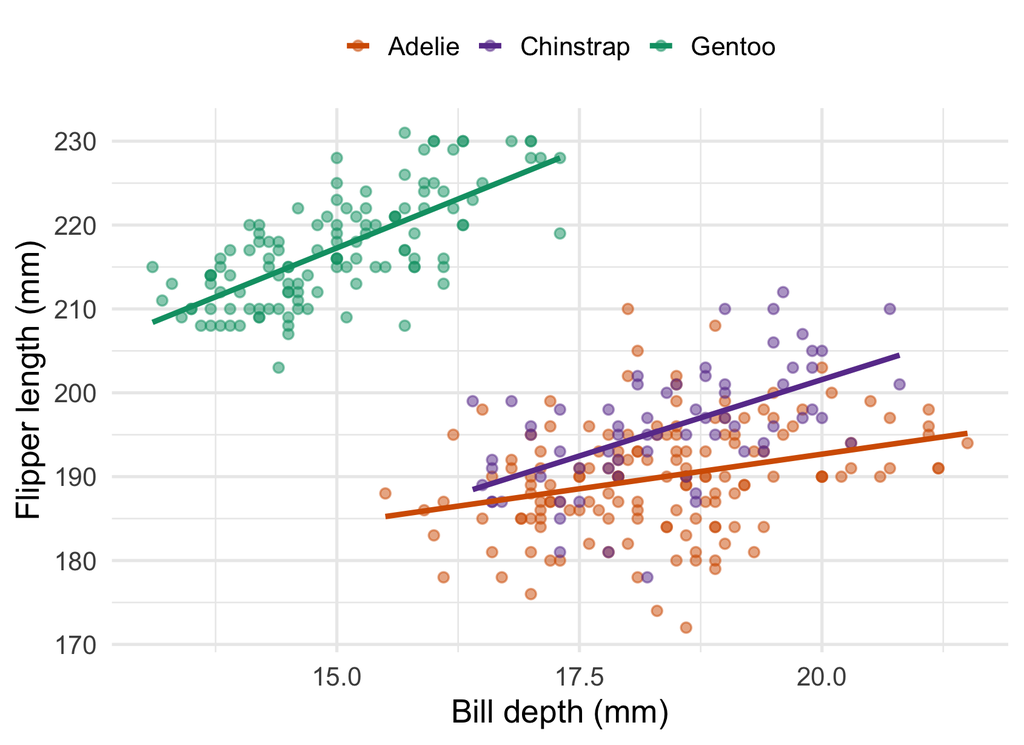

In R, `geom_smooth(method = "lm")` with a `color` variable draws the interaction model:

```r
ggplot(penguins, aes(x = bill_depth_mm,
                     y = flipper_length_mm,
                     color = species)) +
  geom_point() +
  geom_smooth(method = "lm", se = FALSE)
```

The parallel slopes model uses `geom_parallel_slopes(se = FALSE)` (from `moderndive`) instead.

## Interpreting each coefficient

**Fitted model**

$$\begin{aligned}
\widehat{\text{flipper}} = 159.619 &+ 1.653 \times \text{bill depth} \\
&-30.922 \times \text{speciesChinstrap} -12.395 \times \text{speciesGentoo} \\
&+ 1.991 \times \text{bill depth} \times \text{speciesChinstrap} + 3.016 \times \text{bill depth} \times \text{speciesGentoo}
\end{aligned}$$

**Bill depth: $b_1 = 1.653$**

For **Adelie** penguins (the reference level), each additional mm of bill depth is associated with a mean flipper length 1.653 mm longer.

**Interaction terms: $b_{12} = 1.991$, $b_{13} = 3.016$**

The Chinstrap slope is 1.991 mm per mm greater than the Adelie slope. The Gentoo slope is 3.016 mm per mm greater than the Adelie slope.

**Species: $b_2 = -30.922$, $b_3 = -12.395$**

The difference in mean flipper length between Chinstrap (or Gentoo) and Adelie penguins **at a bill depth of 0 mm**. Bill depths range from 13.1 to 21.5 mm, so these values are extrapolation.

- **Intercept ($b_0 = 159.619$):** the mean flipper length for an Adelie penguin with a bill depth of 0 mm. Extrapolation; no interpretation.
- In the interaction model, $b_1$ is the slope **for the reference level only**. It is not “the slope holding species constant.”

## The difference between species depends on bill depth

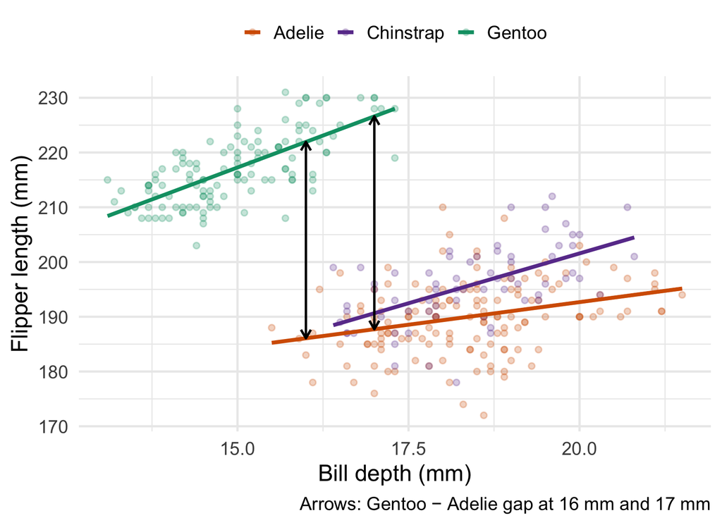

Gentoo − Adelie $= b_3 + b_{13} \times \text{bill depth}$

| Bill depth | Interaction model | Parallel slopes model |
| --- | --- | --- |
| 0 mm | -12.39 | 36.95 |
| 16 mm | 35.87 | 36.95 |
| 17 mm | 38.88 | 36.95 |

In the interaction model, the difference between groups must be stated **at a specific value** of the numerical predictor

## Parallel slopes or interaction?

- **Which model would you recommend for predicting flipper length? Justify your choice using the plots, adjusted $R^2$, and the complexity of each model.**

| Model | R formula | Coefficients | Adjusted R² |
| --- | --- | --- | --- |
| Bill depth only | flipper ~ bill_depth | 2 | 0.339 |
| Species only | flipper ~ species | 3 | 0.777 |
| Parallel slopes: bill depth + species | flipper ~ bill_depth + species | 4 | 0.829 |
| Interaction: bill depth × species | flipper ~ bill_depth * species | 6 | 0.840 |

- The models have different numbers of coefficients, so compare **adjusted** $R^2$.
- **Parsimony:** when two models perform similarly, prefer the one with fewer coefficients.

## When the slopes clearly differ

- **Lego sets (`openintro::lego_population`), Classic vs. DUPLO®: how is price related to the number of pieces?**

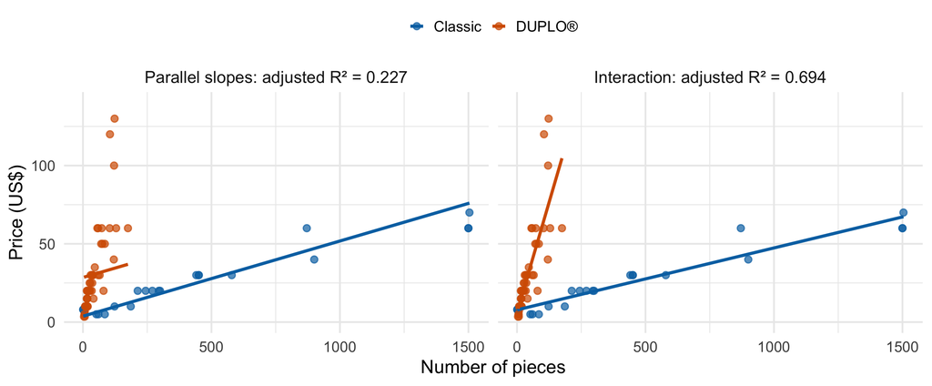

| Theme | Interaction-model slope |
| --- | --- |
| Classic | $0.040 per piece |
| DUPLO® | $0.562 per piece |

## Parallel slopes vs. interaction

|  | Parallel slopes | Interaction |
| --- | --- | --- |
| **In R** | `lm(y ~ x + group)` | `lm(y ~ x * group)` |
| **Plot layer** | `geom_parallel_slopes(se = FALSE)` | `geom_smooth(method = "lm", se = FALSE)` |
| **Assumption** | The slope in $x$ is the **same** for every group | The slope in $x$ **may differ** by group |
| **Picture** | $k$ parallel lines | $k$ lines with different intercepts and slopes |
| **Coefficients** ($k$ groups) | $k + 1$ | $2k$ |
| **$b_1$** | Slope in $x$ for every group | Slope in $x$ for the **reference level** |
| **$b_j$ (group indicator)** | Difference between group $j$ and the reference level at **any** fixed $x$ | Difference between group $j$ and the reference level **at $x = 0$** |
| **$b_{1j}$ (interaction)** | Not in the model | Slope for group $j$ minus slope for the reference level |

## Review: reading model specifications

- **Iris flowers:** $Y$ = petal width (cm), $x$ = sepal width (cm), species = setosa (reference), versicolor, virginica.

| Model | Specification |
| --- | --- |
| **A** | $Y = \beta_0 + \beta_2 \times \text{versicolor} + \beta_3 \times \text{virginica} + \varepsilon$ |
| **B** | $Y = \beta_0 + \beta_1 x + \beta_2 \times \text{versicolor} + \beta_3 \times \text{virginica}$ $\qquad + \beta_{12}\, x \times \text{versicolor} + \beta_{13}\, x \times \text{virginica} + \varepsilon$ |
| **C** | $Y = \beta_0 + \beta_1 x + \varepsilon$ |
| **D** | $Y = \beta_0 + \beta_1 x + \beta_2 \times \text{versicolor} + \beta_3 \times \text{virginica} + \varepsilon$ |

For each model:

1. Write the `lm()` formula and state how many coefficients it has.
2. Describe what a plot of the fitted model looks like.
3. Write the mean petal width for a **virginica** iris with sepal width $x$.
4. Which $\beta$ (or combination of $\beta$’s) is the slope in $x$ for virginica irises?

## Review: reading R output

```r
iris_mod <- lm(Petal.Width ~ Sepal.Width * Species, data = iris)
summary(iris_mod)
```

```
Call:
lm(formula = Petal.Width ~ Sepal.Width * Species, data = iris)

Coefficients:
                              Estimate Std. Error t value Pr(>|t|)
(Intercept)                    0.02418    0.22231   0.109 0.913542
Sepal.Width                    0.06471    0.06447   1.004 0.317176
Speciesversicolor              0.14273    0.31071   0.459 0.646666
Speciesvirginica               0.63988    0.31747   2.016 0.045709 *
Sepal.Width:Speciesversicolor  0.35374    0.10110   3.499 0.000622 ***
Sepal.Width:Speciesvirginica   0.39324    0.09949   3.953 0.000121 ***
---
Signif. codes:  0 '***' 0.001 '**' 0.01 '*' 0.05 '.' 0.1 ' ' 1

Multiple R-squared:  0.9513,    Adjusted R-squared:  0.9496
```

1. Which model (A–D) on the previous slide is this? Which species is the reference level, and how do you know?
2. Write the fitted equation for each species (substitute 0s and 1s, then group the intercept and slope terms).
3. Interpret the `Sepal.Width` coefficient in context.
4. Interpret the `Sepal.Width:Speciesversicolor` coefficient in context.
5. Predict the petal width of a virginica iris with sepal width 3.5 cm.
6. The parallel slopes model (D) has adjusted $R^2$ = 0.943. Which model would you recommend? Justify.